[figure not shown]

**PROBABILITY THEORY AND INTRODUCTORY STATISTICS**  
SWAPNESH TIWARI  
CORRELATION AND REGRESSION  
Date : 12 October, 2022

**Section 1 - Intro**

**Details on the data set**

**History about Correlation and Linear Regression**

Going back to the history of correlation and regression, the very first model of tools used for correlation and regression was developed by Sir Francis Galton in 1888, Denis, D. (2001). But later in 1898, Karl Pearson developed a mathematical equation for correlation which was a more important aspect that is used until now to calculate the relationship between the two variables, Stigler, S. M. (1986). But there is a lot of confusion about whether the work of Auguste Bravais is also related to the invention of correlation techniques, Denis, D. (2001). It would be interesting to know that the very first statistical error was used in the field of astronomy in the 18th century, these techniques were mainly used to determine whether the earth is flat or round., and astronomers were having a hard time figuring out a way to put all the observations into one single value so that measuring the data is more reliable and accurate, Denis, D. (2001). There is also one more person named Robert Adrain who was a famous American mathematician who was thought to have defined the probability for errors the two variables which are independent and dependent to occur at one given point, Walker, H. M. (1929).

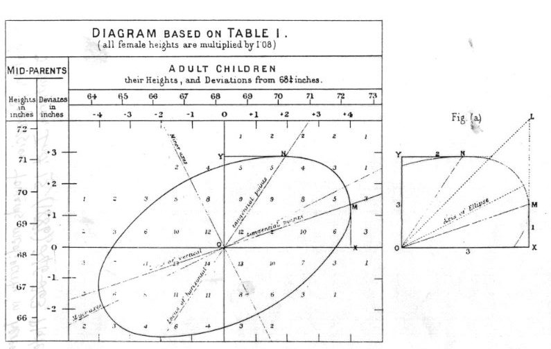

The above figure 1 shows the Galtons “Table of Correlation”, Denis, D. (2001).

In the above diagram we can see that some things are still missing from the Galton’s equation, Galton experimented in 1885 to conclude his regression model with evidence, therefore he selected 928 offspring and their parents, He first generated a table called as Table of Correlation which is presented above, this below table presented the “heights of mid parents against the heights of offspring’s”, so, for example, he described and compared if the height of parent is about 70 inches and if the adult offspring has a height of 67 inches then according to Galton’s diagram he marked it in the particular cell where the data collected form a 90-degree angle.

**Practical applications of correlation in medical industry**

One of the best examples where regression analysis can be used is in the medical industry where researchers use regression analysis to identify the relation between the drug and the outcome of the drug, to better understand this theory let’s take an example from the study published by Azoulay, L. in 2017:

For example, let’s take a drug called sulfonylurea which is an anti-diabetic drug, therefore, a researcher wants to determine if administering a particular anti-diabetic drug can lower the blood glucose level to do this researcher uses co-relation testing, there are two types of variables included in this study, one is the predictor variable , the second is a response variable, predictor variable is the drug and the response variable is the blood glucose level, therefore if we add it to the formula we get :

Blood Sugar Level = B0 + B1(Drug Dose)

Where coefficient B0 is the expected level of blood glucose in the human body when no drug is administered

Where coefficient B1 is the mean change in blood glucose levels when the drug is administered.

If the given B1 is negative then it states that as the drug is administered it will decrease the blood glucose levels.

If the B1 is very close to zero, it will mean that administering the drug has no change in the blood glucose levels.

If the given B1 is positive it will show that administering the drug has increased the blood glucose levels.

So, it all depends on which of the following factors are taken into consideration by the researcher so that decision is made.

**Hypothesis testing in the context of regression analysis**

In contrast to hypothesis testing and linear regression, hypothesis testing bases its foundations mostly on relation between the independent variable and the dependent variable which in the case of linear regression is the variable of response and the other one is the variable that predicts the independent variable. When we approach hypothesis testing through linear regression, we use two types of tests which are F-tests which test if there is no significant difference in variances of the given two populations and they both are equal, on the other, the T-test test is applied when there is unknown stadard deviation of the two populations, but as an analyst, we need to be sure that whatever data we are using it best fits the regression model. Xue, K., & Yao, F. (2021).

**Importance of Final Project**

Analytics is a field where there is an innovation of new things with the help of data, it also provides us evidence if the innovation will be effective, in doing so we need vast amounts of data, Cooper, A. (2012), this course has taught me how to gather data, interpret the data, analyze the data and how to make decisions using the data, some of the techniques included; testing hypothesis with help of critical value and testing hypothesis using the P-value approach, these techniques are essential for me since I will be entering the medical industry as an analyst and these tests are an important factor when testing for the action of drugs. This final project will help develop skills in comparing two populations and developing a hypothesis based on the correlation and regression model. Correlation is an important factor in the medical industry when comparing the effect of drugs while assuming one is the independent and one is the dependent variable as I have given in the example above.

**Advantages of using R**

There are a lot of advantages when using R for data analysis, such as R is easy to use, R has beautiful graphics which we can use to present data, R has a lot of packages that can make the output more informative, R has a lot of statistical tools which can make the analysis more presentable and understandable, the best thing about R is it is open-source software and is supported by many operating systems, R can also be used with SQL to design databases, can also be used with Python and C++ and has numerous more compatibility with other languages, R is a stable software and is reliable for data analysis, Kabacoff, R. I. (2015).

```r
# Library Used in this project

#Important Libraries
library(ggplot2)
library(dplyr)
library(knitr)

#Extra Packages used
library(magrittr)
library(kableExtra)
library(RColorBrewer)



# Open source data sets will be used in this project to practice analysis of data

#Creating a Data object

CarInfo = mpg
```

**Section 2 - Simple Regression**

**1. Description of the data set**

In this task I will be using different codes to fetch the information about the MPG data set which is a part of ggplot2, to do I need ggplot2 library and psych package. I will be using describe code and to make the table in right shape and size I will be rotating the table using the t code which is transpose.

```r
#Created a data set names CarInfo and then used it to fetch details such as Variation, number of samples, measures of central tendency and dispersion.
CarInfo%>%
  dplyr::select("manufacturer", "model", "displ", "year","cyl", "trans", "drv", "cty", "hwy", "fl", "class")%>%
  psych::describe()%>% #Used Psych code to describe the data.
  t()%>% #used transpose to create a good orientation of table.
  round(2)%>% #rounded to two decimals
  knitr::kable( caption = " Table 1 - Descriptive statistics of MPG data set from ggplot2")%>%
  kableExtra::kable_paper()
```

Table 1 - Descriptive statistics of MPG data set from ggplot2

|  | manufacturer* | model* | displ | year | cyl | trans* | drv* | cty | hwy | fl* | class* |
| --- | --- | --- | --- | --- | --- | --- | --- | --- | --- | --- | --- |
| vars | 1.00 | 2.00 | 3.00 | 4.00 | 5.00 | 6.00 | 7.00 | 8.00 | 9.00 | 10.00 | 11.00 |
| n | 234.00 | 234.00 | 234.00 | 234.00 | 234.00 | 234.00 | 234.00 | 234.00 | 234.00 | 234.00 | 234.00 |
| mean | 7.76 | 19.09 | 3.47 | 2003.50 | 5.89 | 5.65 | 1.67 | 16.86 | 23.44 | 4.63 | 4.59 |
| sd | 5.13 | 11.15 | 1.29 | 4.51 | 1.61 | 2.88 | 0.66 | 4.26 | 5.95 | 0.70 | 1.99 |
| median | 6.00 | 18.50 | 3.30 | 2003.50 | 6.00 | 4.00 | 2.00 | 17.00 | 24.00 | 5.00 | 5.00 |
| trimmed | 7.68 | 18.98 | 3.39 | 2003.50 | 5.86 | 5.53 | 1.59 | 16.61 | 23.23 | 4.77 | 4.64 |
| mad | 5.93 | 14.08 | 1.33 | 6.67 | 2.97 | 1.48 | 1.48 | 4.45 | 7.41 | 0.00 | 2.97 |
| min | 1.00 | 1.00 | 1.60 | 1999.00 | 4.00 | 1.00 | 1.00 | 9.00 | 12.00 | 1.00 | 1.00 |
| max | 15.00 | 38.00 | 7.00 | 2008.00 | 8.00 | 10.00 | 3.00 | 35.00 | 44.00 | 5.00 | 7.00 |
| range | 14.00 | 37.00 | 5.40 | 9.00 | 4.00 | 9.00 | 2.00 | 26.00 | 32.00 | 4.00 | 6.00 |
| skew | 0.21 | 0.11 | 0.44 | 0.00 | 0.11 | 0.29 | 0.48 | 0.79 | 0.36 | -2.25 | -0.14 |
| kurtosis | -1.63 | -1.23 | -0.91 | -2.01 | -1.46 | -1.65 | -0.76 | 1.43 | 0.14 | 5.76 | -1.52 |
| se | 0.34 | 0.73 | 0.08 | 0.29 | 0.11 | 0.19 | 0.04 | 0.28 | 0.39 | 0.05 | 0.13 |

**2. Statistics Table**

Imagine we need to know if number of cylinders in car affects the displacement of car, which in turn can affect the performance, to figure it out we need to check the relationship between Displacement and Cylinders, using the unique(CarInfo$cyl) we can see that our MPG data set consist of `4, 6, 8, 5` number of cylinders.

```r
NumOfCylinders = unique(CarInfo$cyl)

#Calculating values for number of cylinders in car respect to displacement.

CarPlot = CarInfo %>%
  group_by(Cylinders = cyl) %>%
  summarise(Mean_Value = mean(displ),
            Standard_Deviation = sd(displ),
            Minimum_Value = min(displ),
            Maximum_Value = max(displ))

#Creating a table to descibe all the values in one
CarPlot %>%
  kable(align = "c",
        caption = "Table 2 - Statistics Of Displacement Per Cylinders In The Mpg Data Set",
        format = "html",
        digits = 2,
        table.attr = "style='width:75%;'")%>%
  kable_paper(bootstrap_options=c("hover","bordered"),
              html_font = "Times New Roman",
              position = "center",
              font_size = 14) %>%
  add_header_above(c(" " = 1,"Displacement" = 4)) #added header so that it accumulates the 4 columns under it.
```

Table 2 - Statistics Of Displacement Per Cylinders In The Mpg Data Set

| Cylinders | Displacement Mean_Value | Displacement Standard_Deviation | Displacement Minimum_Value | Displacement Maximum_Value |
| --- | --- | --- | --- | --- |
| 4 | 2.15 | 0.32 | 1.6 | 2.7 |
| 5 | 2.50 | 0.00 | 2.5 | 2.5 |
| 6 | 3.41 | 0.47 | 2.5 | 4.2 |
| 8 | 5.13 | 0.59 | 4.0 | 7.0 |

From above table we can conclude that if there is increase in number of cylinders there is need to increase the or the displacement of the car increases directly, since if the displacement is low and the number of cylinders are high that can cause misfire and can result in decreased performance. Therefore if the mean in the table is increasing that generally means the displacement of the engine is also increasing as increase in cylinder.For a high performance car it is essential to balance displacement with the number of cylinders but Ferrari did an outstanding job by creating a 1.5 liter engine car with 8 cylinders known as 1.5 l engine 1965 Ferrari 1512, and Chevrolet Corvette having a huge displacement of 7.0L with V8 engines.

**3. Finding Correlation and Determination**

Lets assume I am a racer and I need a very fast car, so I was told that the higher the cylinder the more fast a car is and now I am interested to know if the said words are true therefore I hire a data analyst to give me the data , therefore the data analyst will check for the relationship between the displacement and cylinders of most of the cars and hand me the results:

```r
#Creating objects

Displacement = (CarInfo$displ)
Cylinders = (CarInfo$cyl)
Model = (CarInfo$model)
Manufacturer = (CarInfo$manufacturer)

Model2 = head(Model,15)
Manufacturer2 = head(Manufacturer,15)

DisSum = sum(Displacement)
CylnSum = sum(Cylinders)

DispCyln = Displacement*Cylinders
SumDispCyln = sum(DispCyln)

DisplDet = (Displacement^2)
CylnDet = (Cylinders^2)

n = 234

#Using formula for coefficients

R =  round(n*(SumDispCyln) - (DisSum)*(CylnSum)/sqrt(n*sum(DisplDet))-(DisplDet) * (n*sum(CylnDet) - (sum(CylnDet))), 1)


#Creating objects to display first 10 observations of the table

R10 = head(R, 15)
DisplDet2 = head(DisplDet, 15 )
CylnDet2 = head(CylnDet, 15 )

#Creating matrix to create a good visualization of the values

#Table -1
Objects1  = c(Manufacturer2 , Model2, R10)
Task1table1 = matrix(data = c(Objects1),ncol = 3,byrow = F)
colnames(Task1table1) = c("Manufacturer", "Car Names", "Coefficients")
Matrix =  knitr::kable(Task1table1, caption = "Table 3 - First 15 values of Coefficients of Correlation Between Displacement and Cylinders") %>%
  kableExtra::kable_paper()


#Table -2

Objects2  = c(Manufacturer2 , Model2,DisplDet2, CylnDet2)
Task1table2 = matrix(data = c(Objects2),ncol = 4,byrow = F)
colnames(Task1table2) = c("Manufacturer", "Car Names","Determination of Displacement", "Determination of Cylinders")
Matrix2 =  knitr::kable(Task1table2, caption = "Table 4 - First 15 values of Coefficients of Determination Between Displacement and Cylinders") %>%
  kableExtra::kable_paper(full_width = FALSE)


Matrix
```

| Manufacturer | Car Names | Coefficients |
| --- | --- | --- |
| audi | a4 | -5359110.6 |
| audi | a4 | -5359110.6 |
| audi | a4 | -6903248.2 |
| audi | a4 | -6903248.2 |
| audi | a4 | -14705206.6 |
| audi | a4 | -14705206.6 |
| audi | a4 | -18301421.8 |
| audi | a4 quattro | -5359110.6 |
| audi | a4 quattro | -5359110.6 |
| audi | a4 quattro | -6903248.2 |
| audi | a4 quattro | -6903248.2 |
| audi | a4 quattro | -14705206.6 |
| audi | a4 quattro | -14705206.6 |
| audi | a4 quattro | -18301421.8 |
| audi | a4 quattro | -18301421.8 |

```r
Matrix2
```

| Manufacturer | Car Names | Determination of Displacement | Determination of Cylinders |
| --- | --- | --- | --- |
| audi | a4 | 3.24 | 16 |
| audi | a4 | 3.24 | 16 |
| audi | a4 | 4 | 16 |
| audi | a4 | 4 | 16 |
| audi | a4 | 7.84 | 36 |
| audi | a4 | 7.84 | 36 |
| audi | a4 | 9.61 | 36 |
| audi | a4 quattro | 3.24 | 16 |
| audi | a4 quattro | 3.24 | 16 |
| audi | a4 quattro | 4 | 16 |
| audi | a4 quattro | 4 | 16 |
| audi | a4 quattro | 7.84 | 36 |
| audi | a4 quattro | 7.84 | 36 |
| audi | a4 quattro | 9.61 | 36 |
| audi | a4 quattro | 9.61 | 36 |

**4. Describe the DescTools**

DescTools known as tools for descriptive statistics were first designed by Andri Signorell and colleagues mentioned is a huge collection that consists of various functions in statistics to describe data more effectively, DescTools also consists of various functions which help in the integration of various documents from different formats such as Microsoft Word or Microsoft PowerPoint point and the main thing is data retrieval from Microsoft Excel, there are numerous functions that can help in analysis of data from basic statistical tools to advance tools, which produces summary of different types of variables, it chooses its own suitable graph for the value of X Signorell, A., Aho, K., Alfons, A., Anderegg, N., Aragon, T., Arachchige, C., … & Bolker, B. (2016). DescTools is the fastest way to compute the required data such as Confidence Intervals, lets take an example where DescTools were used to compute the 95 percent confidence interval, therefore in the study done by Bakouny, Z. published in 2021, they used Clopper Pearson method in DescTools to analyze the 95% Confidence interval levels in regards to relationship between cancer and Covid-19.  
One of the codes I am going to use in this task is DESC , which is used to store dichotomous variables in one single plot by producing a dotplot with their corresponding error bars, one similar code is summary.plot, Signorell, A., Aho, K., Alfons, A., Anderegg, N., Aragon, T., Arachchige, C., … & Bolker, B. (2016).

The variable of choice here is Cylinders and displacement from MPG data set.

```r
#Using two variables of interest
DescTools::Desc(mpg$displ)
```

```
## ------------------------------------------------------------------------------
## mpg$displ (numeric)
##
##   length       n    NAs  unique    0s  mean  meanCI'
##      234     234      0      35     0  3.47    3.31
##           100.0%   0.0%          0.0%          3.64
##
##      .05     .10    .25  median   .75   .90     .95
##     1.80    2.00   2.40    3.30  4.60  5.40    5.70
##
##    range      sd  vcoef     mad   IQR  skew    kurt
##     5.40    1.29   0.37    1.33  2.20  0.44   -0.91
##
## lowest : 1.6 (5), 1.8 (14), 1.9 (3), 2.0 (21), 2.2 (6)
## highest: 6.0, 6.1, 6.2 (2), 6.5, 7.0
##
## heap(?): remarkable frequency (9.0%) for the mode(s) (= 2)
##
## ' 95%-CI (classic)
```

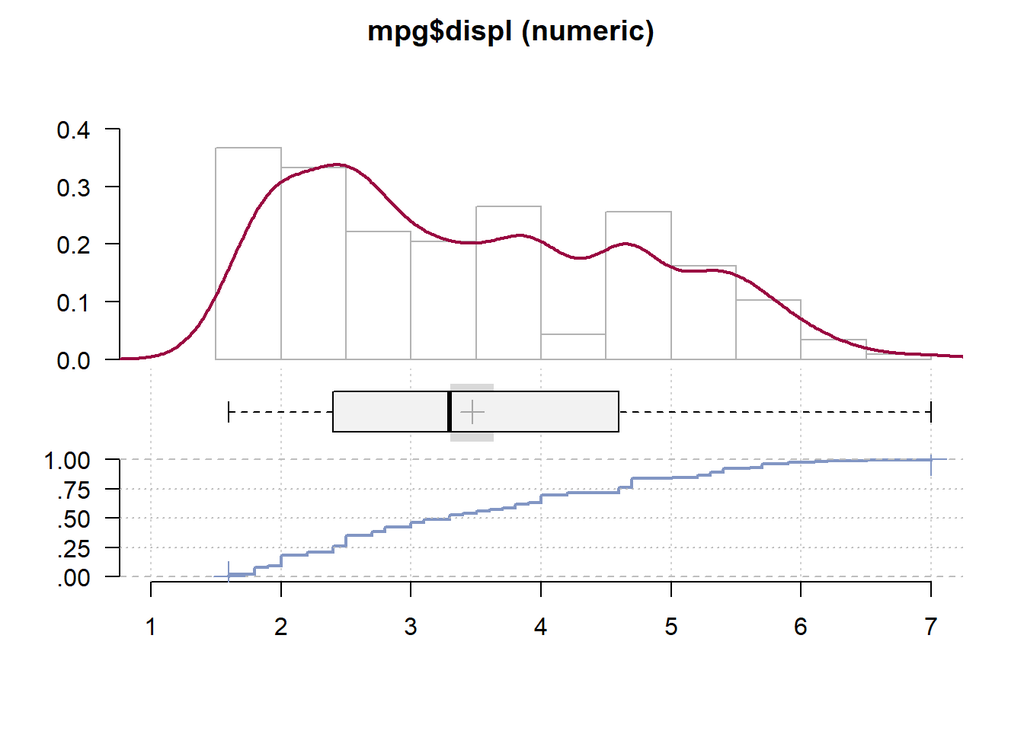

```r
#All the values are relative to 95% confidence interval

DescTools::Desc(mpg$cyl)
```

```
## ------------------------------------------------------------------------------
## mpg$cyl (integer)
##
##   length       n    NAs  unique    0s  mean  meanCI'
##      234     234      0       4     0  5.89    5.68
##           100.0%   0.0%          0.0%          6.10
##
##      .05     .10    .25  median   .75   .90     .95
##     4.00    4.00   4.00    6.00  8.00  8.00    8.00
##
##    range      sd  vcoef     mad   IQR  skew    kurt
##     4.00    1.61   0.27    2.97  4.00  0.11   -1.46
##
##
##    value  freq   perc  cumfreq  cumperc
## 1      4    81  34.6%       81    34.6%
## 2      5     4   1.7%       85    36.3%
## 3      6    79  33.8%      164    70.1%
## 4      8    70  29.9%      234   100.0%
##
## ' 95%-CI (classic)
```

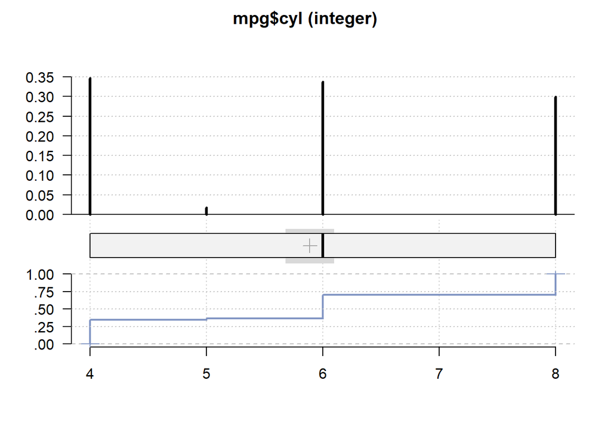

**5. Linear Regression**

Suppose we wanna know what will be the effect of cylinders on displacement in future as we need to predict it and to predict it, this task we will obtain the linear regression between the Cylinders and Displacement

```r
DisSum = sum(Displacement)
CylnSum = sum(Cylinders)

DisplCyln = c(Displacement~Cylinders)

#Using summary to get slope and intercept
SummaryL = summary(DisplCyln)

#Or we can also use lm to get the slope and intercept

RegAnalysis = lm(Displacement~Cylinders) #values for regression formula


#Y = a+bx
#therefore a is the intercept

Intercept = -0.9199
Slope = 0.7458

#Calculating predicting values
YPredict = Intercept+Slope*Cylinders
```

The formula for linear regression model we will use is Y = a+bx where Y is the variable which is dependent variable, a can be denoted by intercept , b can be denoted as slope and x is denoted by independent variable so for our case, Predicted_value = Intercept+Slope*Cylinders the first few answers are = `2.0633, 2.0633, 2.0633, 2.0633, 3.5549` , these following are the predicted values of our regression model in respect of intercept of `-0.9199` and slope = `0.7458` with respect to X variable as Cylinders.

**6. Scatter Plot**

So for example we need to know if number of cylinders can predict the displacement so to get the desired results we will be plotting the above values on a scatter plot , for detailed explanation see the below observation

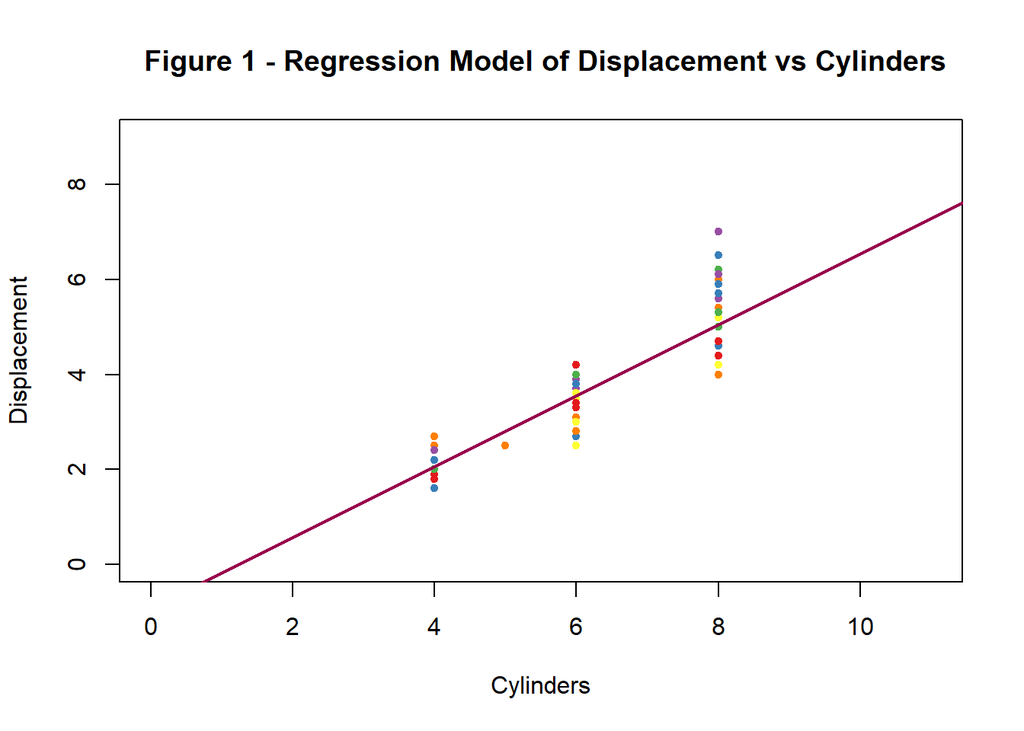

```r
RegPlot = plot(Displacement~Cylinders,
               main = " Figure 1 - Regression Model of Displacement vs Cylinders",
     col= brewer.pal(6, "Set1"),
     pch = 20,
     xlim = c(0,11),
     ylim = c(0,9))

abline(RegAnalysis, col = "#99004C", lty = 1, lwd = 2)
```

Above scatter plot shows dependent variable as Displacement which is a continuous variable.  
Independent variable as Cylinders which is a multiple value discrete.  
There is a strong correlation between cylinders and displacement and thus the data is good fit model.  
Thus if number of cylinders increases, the displacement increases.  
Strong relationship between two variables suggest that displacement can be predicted by number of cylinders.  
Many variables do affect the performance of vehicle such as quality of tires, driving methods and road conditions.

Legend:  
Regression line is marked by a purple line.  
Dots represent the observed values.

**7. Predicted values and residuals**

From the above task we determined how to find the predicted values now we will also retrieve the residual values of the data set, to determine the error we will be encountering in finding the correlation between the number of cylinders and displacement.

```r
#linear regression formula

Data = data.frame( Model, Cylinders, Displacement )

Table2.7 = Data %>%
mutate(YPredict = Intercept + Slope * Displacement, Residue = Displacement-YPredict)

#First 20 observations

Table2.7_1 = head(Table2.7, 20)


#Table -1

Table2.7_1 %>%
  kable(caption = "Table 5 - Prediction and Residul values of Cylinders vs Displacement") %>%
kableExtra:: kable_paper()
```

| Model | Cylinders | Displacement | YPredict | Residue |
| --- | --- | --- | --- | --- |
| a4 | 4 | 1.8 | 0.42254 | 1.37746 |
| a4 | 4 | 1.8 | 0.42254 | 1.37746 |
| a4 | 4 | 2.0 | 0.57170 | 1.42830 |
| a4 | 4 | 2.0 | 0.57170 | 1.42830 |
| a4 | 6 | 2.8 | 1.16834 | 1.63166 |
| a4 | 6 | 2.8 | 1.16834 | 1.63166 |
| a4 | 6 | 3.1 | 1.39208 | 1.70792 |
| a4 quattro | 4 | 1.8 | 0.42254 | 1.37746 |
| a4 quattro | 4 | 1.8 | 0.42254 | 1.37746 |
| a4 quattro | 4 | 2.0 | 0.57170 | 1.42830 |
| a4 quattro | 4 | 2.0 | 0.57170 | 1.42830 |
| a4 quattro | 6 | 2.8 | 1.16834 | 1.63166 |
| a4 quattro | 6 | 2.8 | 1.16834 | 1.63166 |
| a4 quattro | 6 | 3.1 | 1.39208 | 1.70792 |
| a4 quattro | 6 | 3.1 | 1.39208 | 1.70792 |
| a6 quattro | 6 | 2.8 | 1.16834 | 1.63166 |
| a6 quattro | 6 | 3.1 | 1.39208 | 1.70792 |
| a6 quattro | 8 | 4.2 | 2.21246 | 1.98754 |
| c1500 suburban 2wd | 8 | 5.3 | 3.03284 | 2.26716 |
| c1500 suburban 2wd | 8 | 5.3 | 3.03284 | 2.26716 |

**8. Frequency and percentage table**

**I will be obtaining different values for Number of Cylinders against the Frequency of Cars**

```r
CarCyl = table(CarInfo$cyl)
CarFrame = as.data.frame(CarCyl)


names(CarFrame)[names(CarFrame) == "Var1"] = "Number of Cylinders"
names(CarFrame)[names(CarFrame) == "Freq"] = "Frequency_of_Cars"


CarFrame = mutate(CarFrame,
  Cumulative_Frequency = cumsum (CarFrame$Frequency_of_Cars),
  Percentage = round ((Frequency_of_Cars/sum(Frequency_of_Cars)) * 100, 2),
  Cumulative_Percentage = cumsum (Percentage))

knitr::kable(CarFrame, caption = "Table 6 - Cumulative Freqeuncy and Percentage relative to number of Cylinders")%>%
  kableExtra::kable_paper()
```

Table 6 - Cumulative Freqeuncy and Percentage relative to number of Cylinders

| Number of Cylinders | Frequency_of_Cars | Cumulative_Frequency | Percentage | Cumulative_Percentage |
| --- | --- | --- | --- | --- |
| 4 | 81 | 81 | 34.62 | 34.62 |
| 5 | 4 | 85 | 1.71 | 36.33 |
| 6 | 79 | 164 | 33.76 | 70.09 |
| 8 | 70 | 234 | 29.91 | 100.00 |

Overall observation in Task 9

**9. Frequency and percentage Plot**

Using the data from the above table we will be using it to plot different graphs

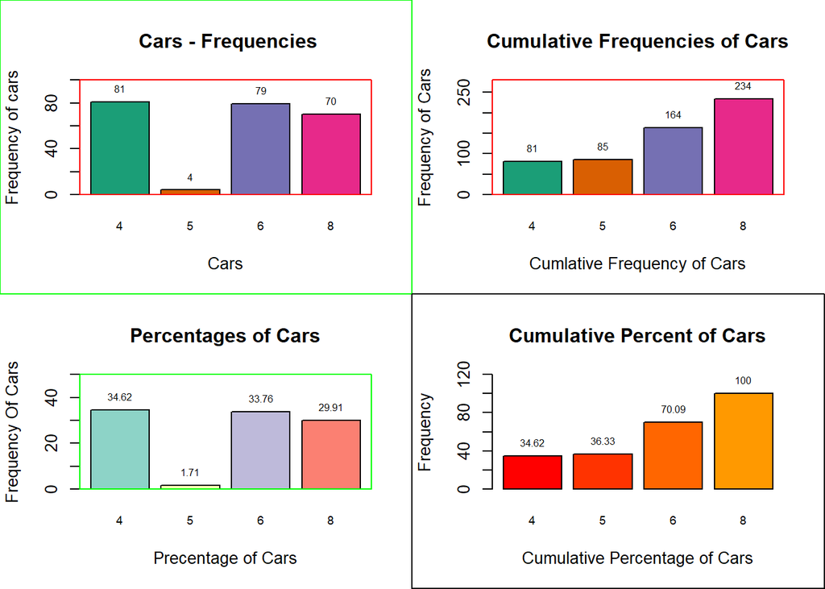

```r
par (mfrow=c(2,2))

# First

CarFreq = barplot(
  CarFrame$Frequency_of_Cars,
  col = brewer.pal(4,"Dark2"),
  cex.names = 0.7,
  ylim = c(0,100),
  names.arg = CarFrame$`Number of Cylinders`,
  main = " Cars - Frequencies",
  xlab = "Cars",
  ylab = "Frequency of cars"
)
text(
  y = CarFrame$Frequency_of_Cars,
  CarFreq,
  CarFrame$Frequency_of_Cars,
  cex = 0.6,
  pos = 3
)
box(which = "plot", col = "red")
box(which = "figure", col = "green")

#Second

CarCumFreq = barplot(
  CarFrame$Cumulative_Frequency,
  col= brewer.pal(4, "Dark2"),
  cex.names = 0.7,
  ylim = c(0,280),
  names.arg = CarFrame$`Number of Cylinders`,
  main = "Cumulative Frequencies of Cars",
  xlab = "Cumlative Frequency of Cars",
  ylab = "Frequency of Cars"
)
text(
  y = CarFrame$Cumulative_Frequency,
  CarCumFreq,
  CarFrame$Cumulative_Frequency,
  cex = 0.6,pos = 3
)

box(which = "plot", col = "red")

#Third

CarPercent = barplot(
  CarFrame$Percentage,
  col= brewer.pal(4, "Set3"),
  cex.names = 0.7,
  ylim = c(0,50),
  names.arg = CarFrame$`Number of Cylinders`,
  main = "Percentages of Cars",
  xlab = "Precentage of Cars",
  ylab = "Frequency Of Cars"
)
text(
  y = CarFrame$Percentage,
  CarPercent,
  CarFrame$Percentage,
  cex = 0.6,pos = 3
)

box(which = "plot", col = "green")

#Fourth

CarCumPercent = barplot(
  CarFrame$Cumulative_Percentage,
  col= heat.colors(8),
  cex.names = 0.7,
  ylim = c(0,120),
  names.arg = CarFrame$`Number of Cylinders`,
  main = "Cumulative Percent of Cars",
  xlab = "Cumulative Percentage of Cars",
  ylab = "Frequency"
)
text(
  y = CarFrame$Cumulative_Percentage,
  CarCumPercent,
  CarFrame$Cumulative_Percentage,
  cex = 0.6,
  pos = 3
)

box(which = "figure")
```

Four of the above graphs are taken from the above table which displays frequencies, percentage, cumulative frequencies and cumulative percentage in relative to the number of cars having 4 cylinders, the highest number of cars are the ones having 4 and 6 cylinders. Observe the last value which is equal to the number of observations in data set, this is because the total number of frequencies keeps on adding as it goes more further, same for the cumulative percentage it reaches 100% at-last, also called as less than cumulative frequency, . The bar plot also shows how many percentage of cars are having 4,5,6,8 cylinders.About 34.62 percent of cars are having 4 cylinder engine which gives automobile industry an idea on how many cylinder cars should be produced more and which one is lacking.

**10. Making predictions from the above values**

Predictions if the car has 2 and 10 cylinders:  
We will use the following formula: Y = a+bx

```r
#as the formula stated above lets define the given values

X1 = 2 #Cylinders
X2 = 10 #Cylinders

#therefore

Intercept = -0.9199
Slope = 0.7458

#What will be displacement if number of cylinders is equal to 2

PredictDispl2 = round(Intercept + Slope * X1,2)

#What will be displacement if number of cylinders is equal to 10

PredictDispl10 = round(Intercept + Slope * X2,2)

#Table
Objects10  = c(PredictDispl2 ,PredictDispl10)
Task10table1 = matrix(data = c(Objects10),ncol = 2,byrow = F)
colnames(Task10table1) = c("Prediction for 2 Cylinder", "Prediction for 10 Cylinder")
Matrix10 =  knitr::kable(Task10table1, caption = "Table 7 - Prediction values for 2 and 10 cylinder engine") %>%
  kableExtra::kable_paper()
Matrix10
```

Table 7 - Prediction values for 2 and 10 cylinder engine

| Prediction for 2 Cylinder | Prediction for 10 Cylinder |
| --- | --- |
| 0.57 | 6.54 |

**Section 3 - Multiple Regression**

**1. Making predictions in multiple regression model**

Assume we need to predict systolic blood pressure in various age groups with various values of weight, so that drug doses can prescribed appropriately and we will know the exact value of Systolic Blood Pressure.

```r
#Data Set
PatientID = c("PK01","PK02","PK03","PK04","PK05","PK06","PK07","PK08","PK09","PK10","PK11","PK12","PK13","PK14","PK15")
SystolicBP =  c(112,156,125,145,155,162,139,144,153,126,169,132,143,153,162)
AGE =  c(45,60,55,60,62,71,57,59,64,42,75,52,59,67,73)
Weight =  c(135,182,148,182,190,232,194,182,217,171,225,173,184,194,211)

#Creating Objects and tables
Objects3.1  = c(PatientID, SystolicBP, AGE, Weight)
Task1table3 = matrix(data = c(Objects3.1),ncol = 4,byrow = F)
colnames(Task1table3) = c("Patient ID", "Systolic BP", "Age of the patient (In Years)", "Weight of the Patient (In Pounds)" )
Matrix3.1 =  knitr::kable(Task1table3, caption = "Table 8 - Patient Details")%>%
  kableExtra:: kable_paper()

#Calculating correlations:

BpAge = round(cor(SystolicBP,AGE),2)
BPWeight = round(cor(Weight,SystolicBP),2)

DetBPAge = round(BpAge^2, 2)
DetBPWeight = round(BPWeight^2, 2)

Matrix3.1.2 = matrix(data = c(BpAge, BPWeight, DetBPAge, DetBPWeight),nrow = 4,ncol = 1, byrow = T)
rownames(Matrix3.1.2) = c("Correlation between BP and Age", "Correlation between BP and Weight", "Determination of BP and Age", "Determination between BP and Weight")
MatrixTable1 = knitr::kable(Matrix3.1.2, caption = "Table 9 - Correlation and Determination between Systolic BP, Age and Weight")%>%
kableExtra:: kable_paper()


#Using F-test for correlation

Reg = lm(SystolicBP ~ AGE+Weight)
#summary(Reg)

RegMulti = round(0.9059 , 2)

#Rounding up the Square root 0.9059 to 0.9056 therefore using the F-test formula we get the following:
FTest3.1 = round((0.906/3) / ((1-0.906) / (15-3-1)), 2)


n= 15
df = n-2
alpha = 0.05

CrticalV2 = round(qt((1-0.05/2),df),2)

#Stating null hypothesis and alternative hypothesis:
#H0 = There is no relationship between systolic blood pressure and the two given variables.
#H1 = There is significant relationship between systolic blood pressure and the two given variables.

#Therefore testing for hypothesis using critical value approach
Hypothesis2 = ifelse(FTest3.1 > CrticalV2 ,"Reject H0", "Fail To Reject H0")



Hypotable1 = matrix(data = c(Hypothesis2),nrow =1 ,ncol = 1, byrow = T)
rownames(Hypotable1) = c("F-Test > Crtical Value = TRUE")
Hypo1 = knitr::kable(Hypotable1)%>%
kableExtra:: kable_paper()



Intercept3.1  = 39.1575
SlopeAge = 0.9824
SlopeWeight = 0.2495

#Systolic blood pressure of a patient of 30 years of age and weight of 148:

SystolicBp1 =  round((Intercept3.1 + SlopeAge * 30 + SlopeWeight* 148),2)

#Systolic blood pressure of a patient for a age of 75 years and weight 196:

SystolicBp2 =  round((Intercept3.1 + SlopeAge * 75 + SlopeWeight* 196),2)



Matrix3.1.3 = matrix(data = c(RegMulti, FTest3.1, CrticalV2, SystolicBp1, SystolicBp2),nrow =5 ,ncol = 1, byrow = T)
rownames(Matrix3.1.3) = c("Multiple R Squared", "F-Test Value", "Critical Value", "Predicted Systolic BP of Age 30 yrs and Weight 148", "Predicted Systolic BP of Age 75 yrs and Weight 196")
Matrix3.1.4 = knitr::kable(Matrix3.1.3, caption = "Table 10 - showing different values as mentioned")%>%
kableExtra:: kable_paper()

Matrix3.1
```

Table 8 - Patient Details

| Patient ID | Systolic BP | Age of the patient (In Years) | Weight of the Patient (In Pounds) |
| --- | --- | --- | --- |
| PK01 | 112 | 45 | 135 |
| PK02 | 156 | 60 | 182 |
| PK03 | 125 | 55 | 148 |
| PK04 | 145 | 60 | 182 |
| PK05 | 155 | 62 | 190 |
| PK06 | 162 | 71 | 232 |
| PK07 | 139 | 57 | 194 |
| PK08 | 144 | 59 | 182 |
| PK09 | 153 | 64 | 217 |
| PK10 | 126 | 42 | 171 |
| PK11 | 169 | 75 | 225 |
| PK12 | 132 | 52 | 173 |
| PK13 | 143 | 59 | 184 |
| PK14 | 153 | 67 | 194 |
| PK15 | 162 | 73 | 211 |

```r
MatrixTable1
```

Table 9 - Correlation and Determination between Systolic BP, Age and Weight

| Correlation between BP and Age | 0.92 |
| --- | --- |
| Correlation between BP and Weight | 0.90 |
| Determination of BP and Age | 0.85 |
| Determination between BP and Weight | 0.81 |

```r
Matrix3.1.4
```

Table 10 - showing different values as mentioned

| Multiple R Squared | 0.91 |
| --- | --- |
| F-Test Value | 35.34 |
| Critical Value | 2.16 |
| Predicted Systolic BP of Age 30 yrs and Weight 148 | 105.56 |
| Predicted Systolic BP of Age 75 yrs and Weight 196 | 161.74 |

```r
Hypo1
```

| F-Test > Crtical Value = TRUE | Reject H0 |
| --- | --- |

**2. Scatter Plots**

I will be plotting scatter plot for two different variables in relation to systolic blood pressure.

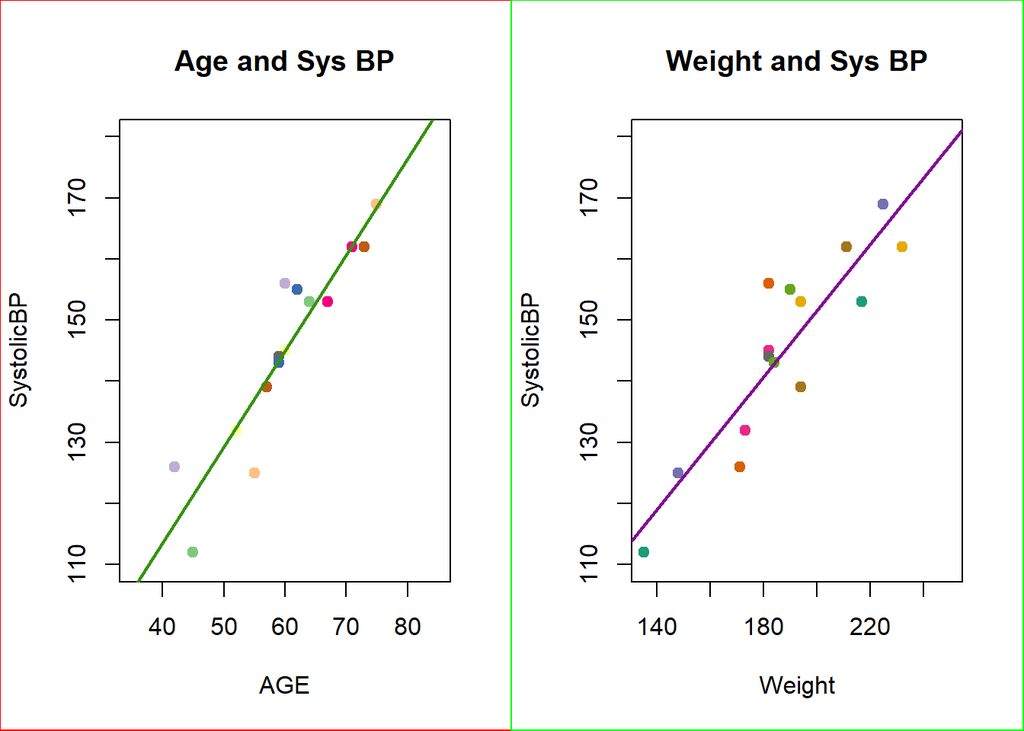

```r
par(mfrow =c(1,2))

#Calculating and plotting regression analysis for Systolic Blood Pressure in regards to Age

RegAGE = lm(SystolicBP  ~  AGE) #Here AGE is our independent variable since Systolic Bp can be affected by age.

AgePlot = plot(AGE,SystolicBP,
                main = "Age and Sys BP",
                col= brewer.pal(8, "Accent"),
                pch = 19,
                ylim= c(110,180),
                xlim = c(35,85))

abline(lm(SystolicBP  ~  AGE), col = "#37920F", lty = 1, lwd = 2)

box(which = "figure", col="red")


#Calculating and plotting regression analysis for Systolic Blood Pressure in regards to Weight
RegWeight = lm(SystolicBP~Weight) #Here weight is our independent variable since obesity leads to Hypertension.

WeightPlot = plot(Weight,SystolicBP,
     col= brewer.pal(8, "Dark2"),
     main = "Weight and Sys BP",
     pch = 19,
     ylim = c(110,180),
     xlim = c(135,250)
  )

abline(lm(SystolicBP ~ Weight), col = "#800F92", lty = 1, lwd = 2)

box(which = "figure", col="green")
```

Legend:  
Regression line is marked by a green line and purple line.  
Dots represent the observed values.

Overall:

1. Predicted value for Y, Predicted Systolic BP of Age 30 yrs and Weight 148, where B1 is age and B2 is weight a = 39.1575 b1 = 0.9824 b2 = 0.2495 x1 = 30 x2 = 148

Therefore, with the formula: Y = a+b1*x1+b2*x2 = `105.56` mmHg 2. Multiple R-squared = `0.91`

**3. Predicted values and Residuals**

From the above information we can see that in the scatter plot we have observed value and the regression line now we need to know the predicted values of the two variables so that we can see if it is reliable to predict the values of Systolic Blood pressure.

```r
Object3.2  = matrix(c(PatientID,AGE,Weight,SystolicBP),nrow = 15,ncol = 4,byrow = F)
colnames(Object3.2) = c("Patient ID","Age of Patient","Weight of Patient","Systolic Blood Pressure")

#Creating dataframe to incorporate table
Table3 = as.data.frame(Object3.2)

#Using linear regression code
AgeBP  = lm(SystolicBP ~ AGE)
SumAgeBP  = summary(AgeBP) #to get multiple R squared value.

#To get selected coefficients
AgeIntercept2 = SumAgeBP$coefficients[1] #to get the estimated intercept
AgeSlope2 = SumAgeBP$coefficients[2,1] # to get the slope of the first variable AGE

WeightBP  = lm(SystolicBP ~ Weight)
SumWeightBP  = summary(WeightBP)

WeightIntercept2 = SumWeightBP$coefficients[1]
SlopeWeight2 = SumWeightBP$coefficients[2,1] # to get the slope of the first variable Weight

Matrix3.3  = Table3 %>%
           mutate(Predicted_by_Age = AgeIntercept2 + AgeSlope2 * AGE, Predicted_by_Weight = WeightIntercept2 + SlopeWeight2* Weight,

                  Residual_by_Age = AGE - Predicted_by_Age, Residual_by_Weight= Weight - Predicted_by_Weight )

knitr::kable(Matrix3.3) %>%
  kableExtra::kable_paper()
```

| Patient ID | Age of Patient | Weight of Patient | Systolic Blood Pressure | Predicted_by_Age | Predicted_by_Weight | Residual_by_Age | Residual_by_Weight |
| --- | --- | --- | --- | --- | --- | --- | --- |
| PK01 | 45 | 135 | 112 | 121.3848 | 116.3651 | -76.38477 | 18.63491 |
| PK02 | 60 | 182 | 156 | 144.9619 | 141.8174 | -84.96188 | 40.18257 |
| PK03 | 55 | 148 | 125 | 137.1028 | 123.4051 | -82.10284 | 24.59490 |
| PK04 | 60 | 182 | 145 | 144.9619 | 141.8174 | -84.96188 | 40.18257 |
| PK05 | 62 | 190 | 155 | 148.1055 | 146.1497 | -86.10549 | 43.85026 |
| PK06 | 71 | 232 | 162 | 162.2518 | 168.8944 | -91.25176 | 63.10561 |
| PK07 | 57 | 194 | 139 | 140.2465 | 148.3159 | -83.24646 | 45.68410 |
| PK08 | 59 | 182 | 144 | 143.3901 | 141.8174 | -84.39007 | 40.18257 |
| PK09 | 64 | 217 | 153 | 151.2491 | 160.7713 | -87.24911 | 56.22870 |
| PK10 | 42 | 171 | 126 | 116.6694 | 135.8605 | -74.66935 | 35.13950 |
| PK11 | 75 | 225 | 169 | 168.5390 | 165.1036 | -93.53899 | 59.89639 |
| PK12 | 52 | 173 | 132 | 132.3874 | 136.9436 | -80.38742 | 36.05642 |
| PK13 | 59 | 184 | 143 | 143.3901 | 142.9005 | -84.39007 | 41.09949 |
| PK14 | 67 | 194 | 153 | 155.9645 | 148.3159 | -88.96453 | 45.68410 |
| PK15 | 73 | 211 | 162 | 165.3954 | 157.5221 | -92.39537 | 53.47793 |

**4. Residuals Plots**

Residuals can be a good statistical tool to determine the accuracy or relaibility of predicting data about the two variables.

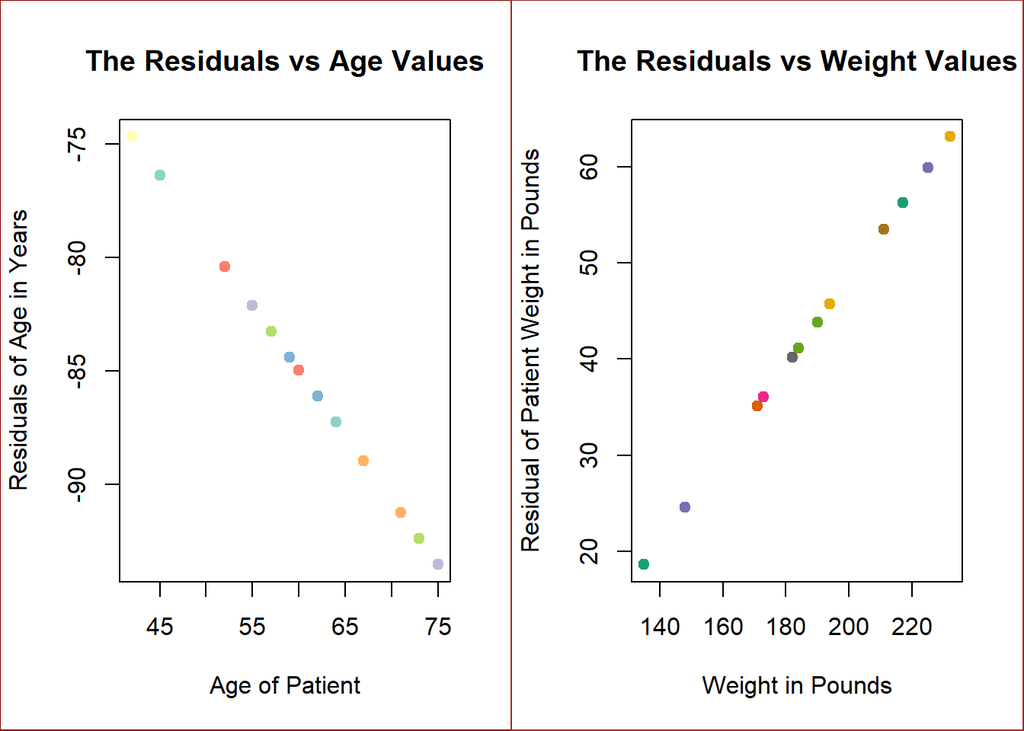

```r
par(mfrow = c(1,2))


#For Age

ResidualAge = c(Matrix3.3$Residual_by_Age)

Ageplot2  = plot(AGE,ResidualAge,
            main = "The Residuals vs Age Values",
            xlab = "Age of Patient",
            ylab = "Residuals of Age in Years",
            col = brewer.pal(8,"Set3"),
            pch = 19)

box(which = "figure", col = "darkred")



#For Weight

ResidualWeight = c(Matrix3.3$Residual_by_Weight)

WeightPlot2 = plot(Weight, ResidualWeight,
            main = "The Residuals vs Weight Values",
            ylab = "Residual of Patient Weight in Pounds",
            xlab = "Weight in Pounds",
            pch = 19,
            col = brewer.pal(8,"Dark2"))

box(which = "figure", col = "brown")
```

Legend:  
Dots represent the observed values.

**Conclusion**

Recommendations:

**References**

Azoulay, L., & Suissa, S. (2017). Sulfonylureas and the risks of cardiovascular events and death: a methodological meta-regression analysis of the observational studies. Diabetes care, 40(5), 706-714.

Bakouny, Z., Paciotti, M., Schmidt, A. L., Lipsitz, S. R., Choueiri, T. K., & Trinh, Q. D. (2021). Cancer screening tests and cancer diagnoses during the COVID-19 pandemic. JAMA oncology, 7(3), 458-460.

Bluman, A. G. (2009). Elementary statistics: A step by step approach. New York: McGraw-Hill Higher Education.

Cooper, A. (2012). What is analytics? Definition and essential characteristics. CETIS Analytics Series, 1(5), 1-10.

Denis, D. (2001). The origins of correlation and regression: Francis Galton or Auguste Bravais and the error theorists. History and Philosophy of Psychology Bulletin, 13(2), 36-44.

Hogg, R. V. (1972). More light on the kurtosis and related statistics. Journal of the American Statistical Association, 67(338), 422-424.

Javanmard, A., & Montanari, A. (2014). Confidence intervals and hypothesis testing for high-dimensional regression. The Journal of Machine Learning Research, 15(1), 2869-2909.

Kabacoff, R. I. (2015). R in Action (2nd ed.). Manning Publications.  
Miller, D., & Millar, I. (1996). The Cambridge dictionary of scientists. Cambridge University Press: Cambridge.

Pearson, K. (1920). Notes on the history of correlation. Biometrika,13, 25-45.

Ribeiro, M. L., Martins, T., Angélico, R. A., Vandepitte, D., & Tita, V. (2012). PROGRESSIVE FAILURE ANALYSIS OF LOW ENERGY IMPACT IN CAR-BON FIBER FILAMENT WINDING CYLINDERS. In 10th World Congress on Computational Mechanics–WCCM.

Signorell, A., Aho, K., Alfons, A., Anderegg, N., Aragon, T., Arachchige, C., … & Bolker, B. (2016). DescTools: Tools for descriptive statistics. R package version 0.99. 18. R Foundation for Statistical Computing, Vienna, Austria.

Stigler, S. M. (1986). The history of statistics: the measurement of uncertainty before 1900. The Belknap Press of Harvard University Press: Cambridge.

Tranmer, M., & Elliot, M. (2008). Multiple linear regression. The Cathie Marsh Centre for Census and Survey Research (CCSR), 5(5), 1-5. Walker, H. M. (1929). Studies in the history of statistical methods. The Williams & Wilkins Company: Baltimore.

Xue, K., & Yao, F. (2021). Hypothesis testing in large-scale functional linear regression. Statistica Sinica, 31, 1101-1123.

Zou, K. H., Tuncali, K., & Silverman, S. G. (2003). Correlation and simple linear regression. Radiology, 227(3), 617-628.

**Appendix**

A rmd file has been attached along with this HTML report named as Tiwari_FinalReport.rmd.